# Kolokwium.Statystyka

Antoniuk Davyd

2024-06-12

```r
library(stats)
library(ggplot2)
```

##Zadanie 1

```r
gleba <- read.table("gleba.csv",sep = ",", header = TRUE)
colSums(is.na(gleba))
```

```
##       X cadmium  copper    lead    zinc    elev    dist
##       0       0       0       0       0       0       0
```

```r
head(gleba)
```

```
##   X cadmium copper lead zinc  elev       dist
## 1 1    11.7     85  299 1022 7.909 0.00135803
## 2 2     8.6     81  277 1141 6.983 0.01222430
## 3 3     6.5     68  199  640 7.800 0.10302900
## 4 4     2.6     81  116  257 7.655 0.19009400
## 5 5     2.8     48  117  269 7.480 0.27709000
## 6 6     3.0     61  137  281 7.791 0.36406700
```

###(A)

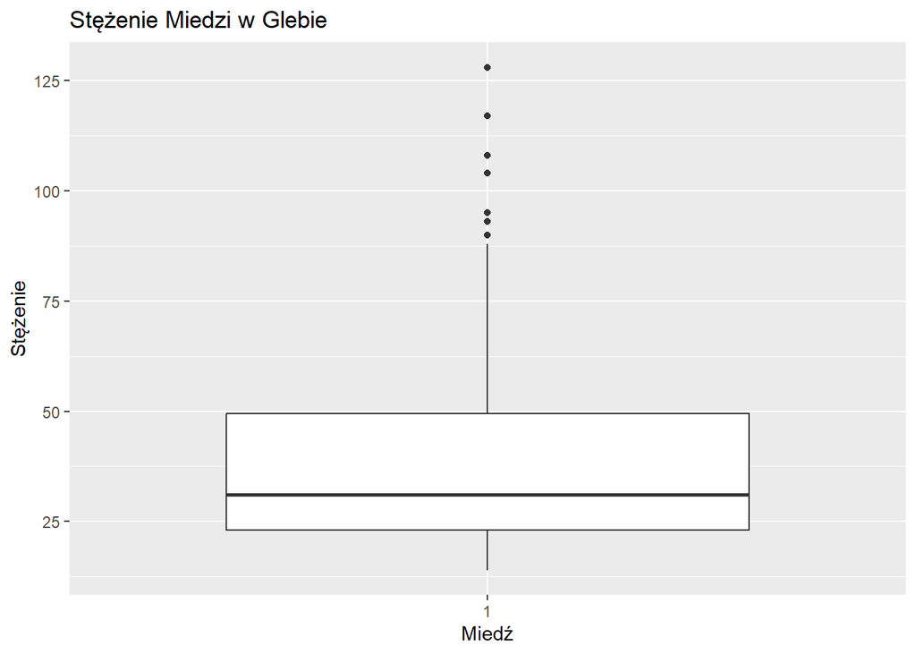

```r
ggplot(gleba, aes(x = factor(1), y = copper)) +
  geom_boxplot() +
  labs(title = "Stężenie Miedzi w Glebie", x = "Miedź", y = "Stężenie",color="blue")
```

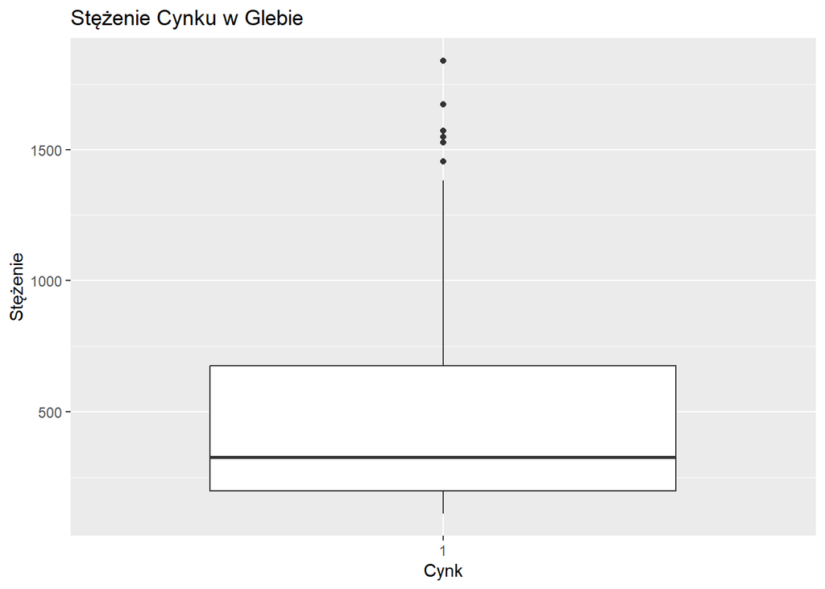

```r
ggplot(gleba, aes(x = factor(1), y = zinc)) +
  geom_boxplot() +
  labs(title = "Stężenie Cynku w Glebie", x = "Cynk", y = "Stężenie",color="lightpink")
```

###(B)

```r
alpha <- 0.04
```

W tym przypadku przeprowadzamy test na równość średnich dwóch populacji. Najpierw musimy przeprowadzić test na równosć wariancji, a zatem przejdziemy do testu na równość średnich.

-TEST NA RÓWNOŚĆ WARIANCJI $H_0:$ Wariancje rozkładów stężenie miedzi i stężeniu cynku są takie same. $H_1:$ Wariancje rozkładów stężenie miedzi i stężeniu cynku są różne.

```r
var.test(gleba$copper, gleba$zinc,conf.level=0.04)
```

```
##
##  F test to compare two variances
##
## data:  gleba$copper and gleba$zinc
## F = 0.0041617, num df = 154, denom df = 154, p-value < 2.2e-16
## alternative hypothesis: true ratio of variances is not equal to 1
## 4 percent confidence interval:
##  0.004128160 0.004195548
## sample estimates:
## ratio of variances
##        0.004161718
```

Przeprowadzilem test var.test.Otrzymłem p-wartość równa 2.2e-16.Otrzymana p-wartość jest mniejszą niż 0.04 więc odrzucamy hipotezę zerową na korzyść hipotezy alternatywnej. Na podstawie otrzymanego testu możemy twierdzić że wariancje rozkładów stężenie miedzi i stężeniu cynku są różne.

```r
t.test(gleba$copper, gleba$zinc,conf.level=0.04,var.equal = FALSE)
```

```
##
##  Welch Two Sample t-test
##
## data:  gleba$copper and gleba$zinc
## t = -14.534, df = 155.28, p-value < 2.2e-16
## alternative hypothesis: true difference in means is not equal to 0
## 4 percent confidence interval:
##  -430.8842 -427.9158
## sample estimates:
## mean of x mean of y
##  40.31613 469.71613
```

###(C)

$H_0:$ Stężenie miedzi i cynku nie są skorelowane. $H_1:$ Stężenie miedzi i cynku są skorelowane.

Estymator punktowy współczynnika korelacji liniowej Pearsona

```r
cor(gleba$copper, gleba$zinc,method = "pearson")
```

```
## [1] 0.9082695
```

Estymator punktowy współczynnika korelacji liniowej Pearsona jest dość duży i dodatni, co wskazuje na to że ze wzrostem stężenie miedzi rośnie stężenie cynku.

```r
cor.test(gleba$copper, gleba$zinc, conf.level = 0.06)
```

```
##
##  Pearson's product-moment correlation
##
## data:  gleba$copper and gleba$zinc
## t = 26.852, df = 153, p-value < 2.2e-16
## alternative hypothesis: true correlation is not equal to 0
## 6 percent confidence interval:
##  0.9071949 0.9093323
## sample estimates:
##       cor
## 0.9082695
```

Test przeprowadziłem korzystając z funkcji “cor.test()”.Z wyniku tej funkcji otrzymałem -wartość statystyki równą - 26.852 -p-wartość równą 2.2e-16 Otrzymana p-wartość jest mniejszą niż 0.06, więc odrzucamy hipotezę zerową na korzyść hipotezy alternatywnej.Na podstawie tych danych możemy twierdzić że stężenie miedzi i cynku są skorelowane. Wspólczynnik korelacji otrzymaliśmy 0.908 który jest dość duży i dodatni, co wskazuje na to że ze wzrostem stężenie miedzi rośnie stężenie cynku.

##Zadanie 2

```r
library(MASS)
```

```r
dane <- anorexia
head(dane)
```

```
##   Treat Prewt Postwt
## 1  Cont  80.7   80.2
## 2  Cont  89.4   80.1
## 3  Cont  91.8   86.4
## 4  Cont  74.0   86.3
## 5  Cont  78.1   76.1
## 6  Cont  88.3   78.1
```

###(A)

```r
n <- 72
```

```r
dane_cbt <- subset(anorexia, Treat == "CBT")

dane_cbt_rozn <- dane_cbt$Postwt - dane_cbt$Prewt

test <- t.test(dane_cbt_rozn)
p_u <- test$conf.int[1:2]
round(p_u,3)
```

```
## [1] 0.227 5.787
```

Około 95 realizacji przedziału (0.227;5.787) na 100 zawiera szacowaną wartość średniej wagi przed i po terapii behawioralnej.

###(B)

$H_0:$ Średnia różnica wagi przed i po terapii behawioralnej wynosi zero $H_1:$ Średnia różnica wagi przed i po terapii behawioralnej jest rózna od 0

```r
t.test(dane_cbt_rozn, alternative = "two.sided")
```

```
##
##  One Sample t-test
##
## data:  dane_cbt_rozn
## t = 2.2156, df = 28, p-value = 0.03502
## alternative hypothesis: true mean is not equal to 0
## 95 percent confidence interval:
##  0.2268902 5.7869029
## sample estimates:
## mean of x
##  3.006897
```

Przeprowadzilem test t.test.Otrzymłem p-wartość równa 0.03502.Otrzymana p-wartość jest mniejszą niż 0.05 więc odrzucamy hipotezę zerową na korzyść hipotezy alternatywnej. Na podstawie otrzymanego testu możemy twierdzić że średnia różnica wagi przed i po terapii behawioralnej jest rózna od 0

## Zadanie 3

```r
n <- 80
czerwone <- 35
biale <- 31
rozowe <- 14

w <- c(czerwone, biale, rozowe)
stos <- c(3, 2, 2)
wszystkie_obserwacje <- n
```

$H_0:$ Stosunek róż czerwonych do białych i różowych wynosi 3:2:2 $H_1:$ Stosunek róż czerwonych do białych i różowych jest inny, niż 3:2:2

```r
ocz <- wszystkie_obserwacje*stos/sum(stos)
ocz
```

```
## [1] 34.28571 22.85714 22.85714
```

```r
p <- ocz/sum(ocz)
sum(p)
```

```
## [1] 1
```

```r
chisq.test(x = w, p = p)
```

```
##
##  Chi-squared test for given probabilities
##
## data:  w
## X-squared = 6.3479, df = 2, p-value = 0.04184
```

Przeprowadzilem test chisq.test.Otrzymłem p-wartość równa 0.04184.Otrzymana p-wartość jest mniejszą niż 0.05 więc odrzucamy hipotezę zerową na korzyść hipotezy alternatywnej. Na podstawie otrzymanego testu możemy twierdzić że stosunek róż czerwonych do białych i różowych jest inny, niż 3:2:2